# Demo: Exploring a CAS Table

### 1. Import Packages and Connect to the CAS Server

Visit the documentation for the SWAT [(SAS Scripting Wrapper for Analytics Transfer)](https://sassoftware.github.io/python-swat/index.html) package.

```python
## Import packages
import swat
import pandas as pd
import matplotlib.pyplot as plt
plt.style.use('seaborn')

## Set options
pd.set_option('display.max_columns', None)

## Connect to CAS
conn = swat.CAS('server.demo.sas.com', 30571, 'student', 'Metadata0', name = 'py03d01')

## Function to load the loans_raw.sashdat file into memory if necessary
def loadLoans():
    conn.loadTable(path ='loans_raw.sashdat', caslib = 'PIVY',
                   casOut = {'name' : 'loans_raw',
                            'caslib' : 'casuser',
                            'promote' : True})
```

### 2. Explore Available CAS Tables

a. Use the tableInfo action to view all available in-memory tables in the **Casuser** caslib. If the **LOANS_RAW** CAS table is not available, uncomment the loadLoans function and execute the cell.

```python
#loadLoans()
conn.tableInfo(caslib = 'casuser')
```

**§ TableInfo**

|  | Name | Label | Rows | Columns | IndexedColumns | Encoding | CreateTimeFormatted | ModTimeFormatted | AccessTimeFormatted | JavaCharSet | CreateTime | ModTime | AccessTime | Global | Repeated | View | MultiPart | SourceName | SourceCaslib | Compressed | Creator | Modifier | SourceModTimeFormatted | SourceModTime |
| --- | --- | --- | --- | --- | --- | --- | --- | --- | --- | --- | --- | --- | --- | --- | --- | --- | --- | --- | --- | --- | --- | --- | --- | --- |
| 0 | CARS | 2004 Car Data | 428 | 15 | 0 | utf-8 | 2022-03-17T19:30:27+00:00 | 2022-03-17T19:30:27+00:00 | 2022-03-17T20:27:32+00:00 | UTF8 | 1.963165e+09 | 1.963165e+09 | 1.963168e+09 | 1 | 0 | 0 | 0 | cars.sas7bdat | PIVY | 0 | student |  | 2021-12-17T18:43:57+00:00 | 1.955386e+09 |
| 1 | LOANS_RAW |  | 16311047 | 20 | 0 | utf-8 | 2022-03-17T20:28:57+00:00 | 2022-03-17T20:28:57+00:00 | 2022-03-17T20:28:57+00:00 | UTF8 | 1.963168e+09 | 1.963168e+09 | 1.963168e+09 | 1 | 0 | 0 | 0 | loans_raw.sashdat | PIVY | 0 | student |  | 2021-12-17T18:40:14+00:00 | 1.955386e+09 |

elapsed 0.00251s · user 0.00168s · sys 0.000276s · mem 0.826MB

b. Reference the **LOANS_RAW** CAS table from the **Casuser** caslib in the variable **tbl** and view the output. Notice that the **tbl** variable references a CAS table.

```python
tbl = conn.CASTable('loans_raw', caslib = 'casuser')
tbl
```

```
CASTable('loans_raw', caslib='casuser')
```

### 3. Preview the Table

a. Preview the CAS table using the head method. The head method processes the data on the CAS server and returns the results to the client as a **SASDataFrame**.

```python
tbl.head()
```

Selected Rows from Table LOANS_RAW

|  | ID | AccNumber | Year | Month | Day | CurrentDate | SalaryGroup | Age | Salary | EmpLength | Category | Amount | InterestRate | LoanLength | LoanGrade | LoanStatus | LastPurchase | Cancelled | CancelledReason | Promotion |
| --- | --- | --- | --- | --- | --- | --- | --- | --- | --- | --- | --- | --- | --- | --- | --- | --- | --- | --- | --- | --- |
| 0 | I-00006307127350009978 | CL3246299535967411-4949000 | 2022.0 | 7.0 | 13.0 | 31DEC2022 | Less than $50,000 | 30.0 | 9128.0 | 11.0 | Car Loan | 14173.66 | 4.26 | 5.0 | C | Current | NaT | 0.0 |  | 0.0 |
| 1 | I-00006307127350009978 | PKEO-1058-5781-4683-1737 | 2020.0 | 7.0 | 16.0 | 31DEC2022 | Less than $50,000 | 30.0 | 9128.0 | 11.0 | Credit Card | 2883.72 | 16.78 | 999999.0 | C | Late | 2022-12-16 | 0.0 |  | 0.0 |
| 2 | I-00006307127350009978 | M9708726115059108-92217000 | 2016.0 | 3.0 | 15.0 | 31DEC2022 | Less than $50,000 | 30.0 | 9128.0 | 11.0 | Mortgage | 13642.37 | 5.00 | 30.0 | C | Current | NaT | 0.0 |  | 0.0 |
| 3 | G-00005046456530690193 | PKEO-0775-3531-9166-5132 | 2020.0 | 2.0 | 10.0 | 31DEC2022 | $50,001 - $100,000 | 46.0 | 92000.0 | 10.0 | Credit Card | 10957.10 | 13.62 | 999999.0 | B | Current | 2022-03-19 | 0.0 |  | 0.0 |
| 4 | C-00006496445944067091 | PKEO-0832-4079-2767-3394 | 2013.0 | 5.0 | 5.0 | 31DEC2022 | Less than $50,000 | 28.0 | 17029.0 | 14.0 | Credit Card | 5257.41 | 21.83 | 999999.0 | B | Current | 2014-08-07 | 0.0 |  | 0.0 |

b. You can use the sort_values method to sort the CAS table in the CAS server, and then use the head method to return five rows from the sorted CAS table. The head method returns a **SASDataFrame** to the client. With the **SASDataFrame**, you can use the Pandas loc method to obtain the columns **ID**, **Year**, **Age**, and **Amount** as you would with a **pandas.DataFrame**.

**Note:** Because the CAS server distributes data blocks among the workers, you must sort the data for guaranteed order.

```python
(tbl
 .sort_values(by = ['Year','Age'],
              ascending = [True,False])
 .head()
 .loc[:,['ID','Year','Age','Amount']])
```

Selected Rows from Table LOANS_RAW

|  | ID | Year | Age | Amount |
| --- | --- | --- | --- | --- |
| 0 | B-00008821645111311227 | 2013.0 | 70.0 | 41556.47 |
| 1 | B-00009109093102160842 | 2013.0 | 70.0 | 1583412.32 |
| 2 | B-00007076930664479733 | 2013.0 | 70.0 | 19456.78 |
| 3 | B-00008821645111311227 | 2013.0 | 70.0 | 414594.89 |
| 4 | B-00006924956047441810 | 2013.0 | 70.0 | 30895.16 |

c. Preview the CAS table using the fetch CAS action. The fetch action processes the results in CAS and returns the summarized results as a **CASResults** object to the client.

```python
tbl.fetch(to = 5)
```

**§ Fetch**

Selected Rows from Table LOANS_RAW

|  | ID | AccNumber | Year | Month | Day | CurrentDate | SalaryGroup | Age | Salary | EmpLength | Category | Amount | InterestRate | LoanLength | LoanGrade | LoanStatus | LastPurchase | Cancelled | CancelledReason | Promotion |
| --- | --- | --- | --- | --- | --- | --- | --- | --- | --- | --- | --- | --- | --- | --- | --- | --- | --- | --- | --- | --- |
| 0 | I-00006307127350009978 | CL3246299535967411-4949000 | 2022.0 | 7.0 | 13.0 | 31DEC2022 | Less than $50,000 | 30.0 | 9128.0 | 11.0 | Car Loan | 14173.66 | 4.26 | 5.0 | C | Current | NaT | 0.0 |  | 0.0 |
| 1 | I-00006307127350009978 | PKEO-1058-5781-4683-1737 | 2020.0 | 7.0 | 16.0 | 31DEC2022 | Less than $50,000 | 30.0 | 9128.0 | 11.0 | Credit Card | 2883.72 | 16.78 | 999999.0 | C | Late | 2022-12-16 | 0.0 |  | 0.0 |
| 2 | I-00006307127350009978 | M9708726115059108-92217000 | 2016.0 | 3.0 | 15.0 | 31DEC2022 | Less than $50,000 | 30.0 | 9128.0 | 11.0 | Mortgage | 13642.37 | 5.00 | 30.0 | C | Current | NaT | 0.0 |  | 0.0 |
| 3 | G-00005046456530690193 | PKEO-0775-3531-9166-5132 | 2020.0 | 2.0 | 10.0 | 31DEC2022 | $50,001 - $100,000 | 46.0 | 92000.0 | 10.0 | Credit Card | 10957.10 | 13.62 | 999999.0 | B | Current | 2022-03-19 | 0.0 |  | 0.0 |
| 4 | C-00006496445944067091 | PKEO-0832-4079-2767-3394 | 2013.0 | 5.0 | 5.0 | 31DEC2022 | Less than $50,000 | 28.0 | 17029.0 | 14.0 | Credit Card | 5257.41 | 21.83 | 999999.0 | B | Current | 2014-08-07 | 0.0 |  | 0.0 |

elapsed 0.00374s · user 0.00204s · sys 0.00159s · mem 1.11MB

d. Sort the results of the fetch action by a single column using the sortBy parameter. The default sort order is ascending.

```python
tbl.fetch(to = 5,
          sortBy = 'Year')
```

**§ Fetch**

Selected Rows from Table LOANS_RAW

|  | ID | AccNumber | Year | Month | Day | CurrentDate | SalaryGroup | Age | Salary | EmpLength | Category | Amount | InterestRate | LoanLength | LoanGrade | LoanStatus | LastPurchase | Cancelled | CancelledReason | Promotion |
| --- | --- | --- | --- | --- | --- | --- | --- | --- | --- | --- | --- | --- | --- | --- | --- | --- | --- | --- | --- | --- |
| 0 | J-00005679261756595224 | PKEO-7937-8329-7146-7161 | 2013.0 | 8.0 | 6.0 | 31DEC2022 | $250,001-$500,000 | 47.0 | 414194.0 | 9.0 | Credit Card | 682.92 | 16.68 | 999999.0 | A | Current | 2022-12-30 | 0.0 |  | 0.0 |
| 1 | J-00005621705893427134 | PKEO-6092-2564-9807-4925 | 2013.0 | 8.0 | 7.0 | 31DEC2022 | $100,001 - $250,000 | 60.0 | 174900.0 | 16.0 | Credit Card | 7709.03 | 19.79 | 999999.0 | A | Current | 2022-12-11 | 0.0 |  | 0.0 |
| 2 | J-00007106445506215096 | PKEO-9680-0877-3159-8701 | 2013.0 | 7.0 | 15.0 | 31DEC2022 | Less than $50,000 | 31.0 | 8006.0 | 24.0 | Credit Card | 1291.04 | 24.24 | 999999.0 | D | Current | 2022-12-27 | 0.0 |  | 0.0 |
| 3 | H-00001117101171985269 | CL25146321998909134745900001 | 2013.0 | 8.0 | 12.0 | 31DEC2022 | Less than $50,000 | 46.0 | 19289.0 | 10.0 | Consolidation | 2472.97 | 10.50 | 7.0 | D | Fully Paid | NaT | 0.0 |  | 0.0 |
| 4 | C-00006496445944067091 | PKEO-0832-4079-2767-3394 | 2013.0 | 5.0 | 5.0 | 31DEC2022 | Less than $50,000 | 28.0 | 17029.0 | 14.0 | Credit Card | 5257.41 | 21.83 | 999999.0 | B | Current | 2014-08-07 | 0.0 |  | 0.0 |

elapsed 1.93s · user 1.78s · sys 0.148s · mem 750MB

e. Sort the results of the fetch action by multiple columns by passing a list to the sortBy parameter.

```python
tbl.fetch(to = 5,
          sortBy = ['Year', 'Age'])
```

**§ Fetch**

Selected Rows from Table LOANS_RAW

|  | ID | AccNumber | Year | Month | Day | CurrentDate | SalaryGroup | Age | Salary | EmpLength | Category | Amount | InterestRate | LoanLength | LoanGrade | LoanStatus | LastPurchase | Cancelled | CancelledReason | Promotion |
| --- | --- | --- | --- | --- | --- | --- | --- | --- | --- | --- | --- | --- | --- | --- | --- | --- | --- | --- | --- | --- |
| 0 | C-00001463558170944453 | PKEO-6651-2472-9444-6430 | 2013.0 | 6.0 | 20.0 | 31DEC2022 | Less than $50,000 | 18.0 | 10959.0 | 5.0 | Credit Card | 0.00 | 21.66 | 999999.0 | B | Fully Paid | 2018-02-11 | 0.0 |  | 0.0 |
| 1 | B-00007439366055186838 | SB2777748119551690-6757000 | 2013.0 | 2.0 | 5.0 | 31DEC2022 | Less than $50,000 | 18.0 | 3940.0 | 11.0 | Small Business | 3031.47 | 18.23 | 10.0 | E | Current | NaT | 0.0 |  | 0.0 |
| 2 | F-00006002302791457623 | SB9480339870788158-8457300 | 2013.0 | 9.0 | 27.0 | 31DEC2022 | Less than $50,000 | 18.0 | 4861.0 | 1.0 | Small Business | 2902.20 | 11.55 | 5.0 | D | Fully Paid | NaT | 0.0 |  | 0.0 |
| 3 | I-00006112415231764317 | PKEO-1088-7770-6207-0560 | 2013.0 | 8.0 | 4.0 | 31DEC2022 | Less than $50,000 | 18.0 | 3313.0 | 13.0 | Credit Card | 3616.56 | 26.00 | 999999.0 | D | Default | 2022-12-26 | 0.0 |  | 0.0 |
| 4 | J-00005408420856110752 | HI4694779317360372-9601300 | 2013.0 | 6.0 | 6.0 | 31DEC2022 | Less than $50,000 | 18.0 | 9214.0 | 11.0 | Home Improvement | 4267.54 | 0.00 | 1.5 | B | Fully Paid | NaT | 0.0 |  | 1.0 |

elapsed 2.14s · user 1.92s · sys 0.209s · mem 876MB

f. The fetch action allows you to modify the sort order for each column specified within the action. Here, sort the CAS table by ascending **Year** and descending **Age** by specifying a list of columns to sort in the sortBy parameter. Within the list, you can specify a single column to accept the default sort, or you can add a dictionary to modify the sort order.

```python
tbl.fetch(to = 5,
          sortBy = ['Year',
                    {'name':'Age', 'order':'descending'}
                   ])
```

**§ Fetch**

Selected Rows from Table LOANS_RAW

|  | ID | AccNumber | Year | Month | Day | CurrentDate | SalaryGroup | Age | Salary | EmpLength | Category | Amount | InterestRate | LoanLength | LoanGrade | LoanStatus | LastPurchase | Cancelled | CancelledReason | Promotion |
| --- | --- | --- | --- | --- | --- | --- | --- | --- | --- | --- | --- | --- | --- | --- | --- | --- | --- | --- | --- | --- |
| 0 | B-00008821645111311227 | CL24088011169806144695200008 | 2013.0 | 2.0 | 15.0 | 31DEC2022 | $250,001-$500,000 | 70.0 | 234291.0 | 16.0 | Consolidation | 41556.47 | 8.05 | 10.0 | A | Current | NaT | 0.0 |  | 0.0 |
| 1 | B-00009109093102160842 | M6648674737662078-63520000 | 2013.0 | 4.0 | 26.0 | 31DEC2022 | Greater than $500,001 | 70.0 | 905806.0 | 11.0 | Mortgage | 1583412.32 | 4.28 | 30.0 | A | Current | NaT | 0.0 |  | 0.0 |
| 2 | B-00007076930664479733 | MD8208610170986504-1122000 | 2013.0 | 5.0 | 26.0 | 31DEC2022 | $250,001-$500,000 | 70.0 | 381687.0 | 9.0 | Medical | 19456.78 | 9.92 | 5.0 | C | Fully Paid | NaT | 0.0 |  | 0.0 |
| 3 | B-00008821645111311227 | M2059938285965474-80574000 | 2013.0 | 9.0 | 24.0 | 31DEC2022 | $250,001-$500,000 | 70.0 | 234291.0 | 16.0 | Mortgage | 414594.89 | 4.33 | 30.0 | A | Current | NaT | 0.0 |  | 0.0 |
| 4 | B-00006924956047441810 | SB9158684450667352-7007200 | 2013.0 | 2.0 | 14.0 | 31DEC2022 | $250,001-$500,000 | 70.0 | 408629.0 | 22.0 | Small Business | 30895.16 | 5.38 | 7.0 | A | Fully Paid | NaT | 0.0 |  | 0.0 |

elapsed 2.12s · user 1.93s · sys 0.185s · mem 876MB

g. You can also select specific columns within the action. Here, use the fetchVars parameter and specify the following list of columns: **ID**, **Year**, **Age**, and **Amount**.

```python
tbl.fetch(to = 5,
          sortBy = ['Year',
                    {'name':'Age', 'order':'descending'}
                   ],
          fetchVars = ['ID','Year','Age','Amount'])
```

**§ Fetch**

Selected Rows from Table LOANS_RAW

|  | ID | Year | Age | Amount |
| --- | --- | --- | --- | --- |
| 0 | B-00008821645111311227 | 2013.0 | 70.0 | 41556.47 |
| 1 | B-00009109093102160842 | 2013.0 | 70.0 | 1583412.32 |
| 2 | B-00007076930664479733 | 2013.0 | 70.0 | 19456.78 |
| 3 | B-00008821645111311227 | 2013.0 | 70.0 | 414594.89 |
| 4 | B-00006924956047441810 | 2013.0 | 70.0 | 30895.16 |

elapsed 1.9s · user 1.72s · sys 0.174s · mem 876MB

### 4. Explore a CAS Table

a. View the CAS table dimensions using the shape attribute. The shape attribute returns a **tuple** to the client.

```python
tbl.shape
```

```
(16311047, 20)
```

b. Use the [simple.numRows](https://go.documentation.sas.com/doc/en/pgmsascdc/v_016/casanpg/cas-simple-numrows.htm?homeOnFail) action to display the number of rows in a CAS table.

```python
tbl.numRows()
```

**§ numrows**

16311047

elapsed 0.000888s · user 0.000756s · mem 0.418MB

c. View the column names of a CAS table using the columns attribute.

```python
tbl.columns
```

```
Index(['ID', 'AccNumber', 'Year', 'Month', 'Day', 'CurrentDate', 'SalaryGroup',
       'Age', 'Salary', 'EmpLength', 'Category', 'Amount', 'InterestRate',
       'LoanLength', 'LoanGrade', 'LoanStatus', 'LastPurchase', 'Cancelled',
       'CancelledReason', 'Promotion'],
      dtype='object')
```

d. View the data types of the CAS table columns using the familiar dtypes attribute.

```python
tbl.dtypes
```

```
ID                 varchar
AccNumber          varchar
Year                double
Month               double
Day                 double
CurrentDate        varchar
SalaryGroup        varchar
Age                 double
Salary              double
EmpLength           double
Category           varchar
Amount              double
InterestRate        double
LoanLength          double
LoanGrade          varchar
LoanStatus         varchar
LastPurchase        double
Cancelled           double
CancelledReason    varchar
Promotion           double
dtype: object
```

e. Use the [table.columnInfo](https://go.documentation.sas.com/doc/en/pgmsascdc/v_016/caspg/cas-table-columninfo.htm) action to show a CAS table's column information. The columnInfo action shows additional CAS table column information like column labels and formats if they exist. The columnInfo action is recommended instead of dtypes.

```python
tbl.columnInfo()
```

**§ ColumnInfo**

|  | Column | Label | ID | Type | RawLength | FormattedLength | Format | NFL | NFD |
| --- | --- | --- | --- | --- | --- | --- | --- | --- | --- |
| 0 | ID |  | 1 | varchar | 30 | 30 |  | 0 | 0 |
| 1 | AccNumber |  | 2 | varchar | 30 | 30 |  | 0 | 0 |
| 2 | Year |  | 3 | double | 8 | 12 |  | 0 | 0 |
| 3 | Month |  | 4 | double | 8 | 12 |  | 0 | 0 |
| 4 | Day |  | 5 | double | 8 | 12 |  | 0 | 0 |
| 5 | CurrentDate |  | 6 | varchar | 9 | 9 |  | 0 | 0 |
| 6 | SalaryGroup |  | 7 | varchar | 22 | 22 |  | 0 | 0 |
| 7 | Age |  | 8 | double | 8 | 12 |  | 0 | 0 |
| 8 | Salary |  | 9 | double | 8 | 12 |  | 0 | 0 |
| 9 | EmpLength |  | 10 | double | 8 | 12 |  | 0 | 0 |
| 10 | Category |  | 11 | varchar | 16 | 16 |  | 0 | 0 |
| 11 | Amount |  | 12 | double | 8 | 12 |  | 0 | 0 |
| 12 | InterestRate |  | 13 | double | 8 | 12 |  | 0 | 0 |
| 13 | LoanLength |  | 14 | double | 8 | 12 |  | 0 | 0 |
| 14 | LoanGrade |  | 15 | varchar | 1 | 1 |  | 0 | 0 |
| 15 | LoanStatus |  | 16 | varchar | 10 | 10 |  | 0 | 0 |
| 16 | LastPurchase |  | 17 | double | 8 | 9 | DATE | 9 | 0 |
| 17 | Cancelled |  | 18 | double | 8 | 12 |  | 0 | 0 |
| 18 | CancelledReason |  | 19 | varchar | 13 | 13 |  | 0 | 0 |
| 19 | Promotion |  | 20 | double | 8 | 12 |  | 0 | 0 |

elapsed 0.00132s · user 0.000933s · sys 0.000245s · mem 0.83MB

### 5. View Distinct and Missing Values

a. Use the info method to print a summary of CAS table information. The info method returns information like the number of nonmissing values, column type, data size, and more.

```python
tbl.info()
```

```
CASTable('loans_raw', caslib='casuser')
Data columns (total 20 columns):
                        N   Miss     Type
ID               16311047  False  varchar
AccNumber        16311047  False  varchar
Year             16311047  False   double
Month            16311047  False   double
Day              16311047  False   double
CurrentDate      16311047  False  varchar
SalaryGroup      16311047  False  varchar
Age              16311047  False   double
Salary           16311047  False   double
EmpLength        16248780   True   double
Category         16311047  False  varchar
Amount           16311047  False   double
InterestRate     16311047  False   double
LoanLength       16311047  False   double
LoanGrade        16311047  False  varchar
LoanStatus       16311047  False  varchar
LastPurchase      8634724   True   double
Cancelled        16311047  False   double
CancelledReason    158274   True  varchar
Promotion        16311047  False   double
dtypes: double(12), varchar(8)
data size: 5183394003
vardata size: 1529719475
memory usage: 0
```

b. Use the nmiss method to view the number of missing values in each column of a CAS table. The CAS server returns a **series** to the client.

```python
tbl.nmiss()
```

```
ID                        0
AccNumber                 0
Year                      0
Month                     0
Day                       0
CurrentDate               0
SalaryGroup               0
Age                       0
Salary                    0
EmpLength             62267
Category                  0
Amount                    0
InterestRate              0
LoanLength                0
LoanGrade                 0
LoanStatus                0
LastPurchase        7676323
Cancelled                 0
CancelledReason    16152773
Promotion                 0
dtype: int64
```

c. Use the [simple.distinct](https://documentation.sas.com/doc/en/pgmsascdc/v_018/casanpg/cas-simple-distinct.htm?homeOnFail) action to get the number of distinct and missing values for every column. Store the **SASDataFrame** from within the **CASResults** object in the variable **df** by calling the *Distinct* key after the action.

**Note:** The distinct action is resource intensive, it can take some time to complete execution depending on the environment.

```python
##Execute the distinct action and store the SASDataFrame from the CASResults object
df = tbl.distinct()['Distinct']
df
```

Distinct Counts for LOANS_RAW

|  | Column | NDistinct | NMiss | Trunc |
| --- | --- | --- | --- | --- |
| 0 | ID | 7199417.0 | 0.0 | 0.0 |
| 1 | AccNumber | 16311047.0 | 0.0 | 0.0 |
| 2 | Year | 10.0 | 0.0 | 0.0 |
| 3 | Month | 12.0 | 0.0 | 0.0 |
| 4 | Day | 27.0 | 0.0 | 0.0 |
| 5 | CurrentDate | 1.0 | 0.0 | 0.0 |
| 6 | SalaryGroup | 5.0 | 0.0 | 0.0 |
| 7 | Age | 53.0 | 0.0 | 0.0 |
| 8 | Salary | 607779.0 | 0.0 | 0.0 |
| 9 | EmpLength | 36.0 | 62267.0 | 0.0 |
| 10 | Category | 13.0 | 0.0 | 0.0 |
| 11 | Amount | 4730503.0 | 0.0 | 0.0 |
| 12 | InterestRate | 3231.0 | 0.0 | 0.0 |
| 13 | LoanLength | 10.0 | 0.0 | 0.0 |
| 14 | LoanGrade | 5.0 | 0.0 | 0.0 |
| 15 | LoanStatus | 6.0 | 0.0 | 0.0 |
| 16 | LastPurchase | 3621.0 | 7676323.0 | 0.0 |
| 17 | Cancelled | 2.0 | 0.0 | 0.0 |
| 18 | CancelledReason | 7.0 | 16152773.0 | 0.0 |
| 19 | Promotion | 2.0 | 0.0 | 0.0 |

### 6. Calculate the Percentage of Distinct Values for Each Column

a. Confirm that the variable **df** contains a **SASDataFrame** and then display the results. Remember, the **SASDataFrame** resides on the client.

```python
display(type(df), df)
```

```
swat.dataframe.SASDataFrame
```

Distinct Counts for LOANS_RAW

|  | Column | NDistinct | NMiss | Trunc |
| --- | --- | --- | --- | --- |
| 0 | ID | 7199417.0 | 0.0 | 0.0 |
| 1 | AccNumber | 16311047.0 | 0.0 | 0.0 |
| 2 | Year | 10.0 | 0.0 | 0.0 |
| 3 | Month | 12.0 | 0.0 | 0.0 |
| 4 | Day | 27.0 | 0.0 | 0.0 |
| 5 | CurrentDate | 1.0 | 0.0 | 0.0 |
| 6 | SalaryGroup | 5.0 | 0.0 | 0.0 |
| 7 | Age | 53.0 | 0.0 | 0.0 |
| 8 | Salary | 607779.0 | 0.0 | 0.0 |
| 9 | EmpLength | 36.0 | 62267.0 | 0.0 |
| 10 | Category | 13.0 | 0.0 | 0.0 |
| 11 | Amount | 4730503.0 | 0.0 | 0.0 |
| 12 | InterestRate | 3231.0 | 0.0 | 0.0 |
| 13 | LoanLength | 10.0 | 0.0 | 0.0 |
| 14 | LoanGrade | 5.0 | 0.0 | 0.0 |
| 15 | LoanStatus | 6.0 | 0.0 | 0.0 |
| 16 | LastPurchase | 3621.0 | 7676323.0 | 0.0 |
| 17 | Cancelled | 2.0 | 0.0 | 0.0 |
| 18 | CancelledReason | 7.0 | 16152773.0 | 0.0 |
| 19 | Promotion | 2.0 | 0.0 | 0.0 |

b. Use the numRows action to store the number of rows in the **LOANS_RAW** CAS table. Call the *numrows* key to return the number to the variable **n**.

```python
n = tbl.numRows()['numrows']
n
```

```
16311047
```

c. Because **df** is a **SASDataFrame**, you can use traditional Pandas functionality. Using traditional Pandas on the client, add a new column named **pctDistinct** to the **SASDataFrame** that divides the total number of distinct values by the total rows in the table and round the value. Then sort the **SASDataFrame** by the new **pctDistinct** column.

```python
## Create a new column named pctDistinct
df['pctDistinct'] = round(df.NDistinct/n, ndigits = 6)

## Sort the DataFrame by the pctDistinct column
df.sort_values(by = 'pctDistinct',
               ascending = False,
               inplace = True)

## View the SASDataFrame
df
```

Distinct Counts for LOANS_RAW

|  | Column | NDistinct | NMiss | Trunc | pctDistinct |
| --- | --- | --- | --- | --- | --- |
| 1 | AccNumber | 16311047.0 | 0.0 | 0.0 | 1.000000 |
| 0 | ID | 7199417.0 | 0.0 | 0.0 | 0.441383 |
| 11 | Amount | 4730503.0 | 0.0 | 0.0 | 0.290018 |
| 8 | Salary | 607779.0 | 0.0 | 0.0 | 0.037262 |
| 16 | LastPurchase | 3621.0 | 7676323.0 | 0.0 | 0.000222 |
| 12 | InterestRate | 3231.0 | 0.0 | 0.0 | 0.000198 |
| 7 | Age | 53.0 | 0.0 | 0.0 | 0.000003 |
| 4 | Day | 27.0 | 0.0 | 0.0 | 0.000002 |
| 9 | EmpLength | 36.0 | 62267.0 | 0.0 | 0.000002 |
| 13 | LoanLength | 10.0 | 0.0 | 0.0 | 0.000001 |
| 10 | Category | 13.0 | 0.0 | 0.0 | 0.000001 |
| 3 | Month | 12.0 | 0.0 | 0.0 | 0.000001 |
| 2 | Year | 10.0 | 0.0 | 0.0 | 0.000001 |
| 6 | SalaryGroup | 5.0 | 0.0 | 0.0 | 0.000000 |
| 5 | CurrentDate | 1.0 | 0.0 | 0.0 | 0.000000 |
| 14 | LoanGrade | 5.0 | 0.0 | 0.0 | 0.000000 |
| 15 | LoanStatus | 6.0 | 0.0 | 0.0 | 0.000000 |
| 17 | Cancelled | 2.0 | 0.0 | 0.0 | 0.000000 |
| 18 | CancelledReason | 7.0 | 16152773.0 | 0.0 | 0.000000 |
| 19 | Promotion | 2.0 | 0.0 | 0.0 | 0.000000 |

d. Use the Pandas plot method to plot the **PctDistinct** column in the **SASDataFrame**. The visualization displays the percentage of distinct values for each column.

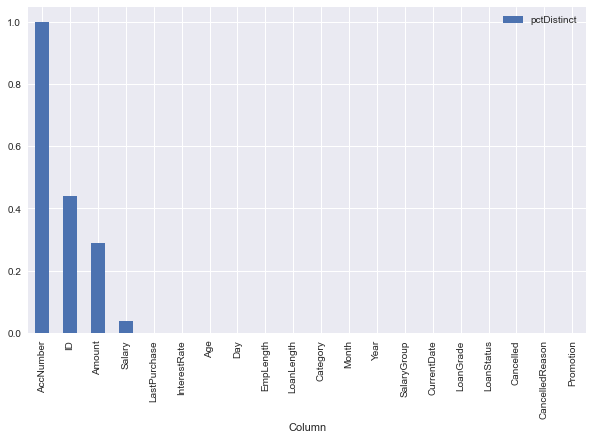

```python
df.plot(kind = 'bar', x = 'Column', y = 'pctDistinct',
        figsize=(10,6));
```

### 7. Terminate the CAS Session

It's best practice to always terminate the CAS session when you are done.

```python
conn.terminate()
```